Escreva seu nome: GABARITO

# Avaliação Final de Ciência dos dados

**2020 - 1o. semestre**

## Instruções

**Leia atentamente as instruções da Avaliação FINAL. Essas devem ser seguidas rigorosamente!**

**Prezado(a) Aluno(a),**

Você terá **135 minutos** a partir do início oficial da prova (**às 13h30 do dia 18/06**) para concluir esta avaliação, administre bem o seu tempo.

Esta avaliação terá as seguintes etapas:

**13h30 às 13h35**

- **(1 minuto) - Momento ZERO:** às 13h30 já esteja na equipe de Ciência dos dados (canal Geral) para receber instruções.
- **(3 minutos) - Início da prova:** Entre no Blackboard e inicie o teste em `Conteúdos/Avaliações/Avaliação Final/Avaliação Final`. Caso não ative esse teste em até 15 minutos do início da prova (ou seja, até às 13h45), não terá mais direito de entregar essa prova, obtendo falta na mesma.
- **(1 minuto) - Prova no servidor:** Entre no seu e-mail do Insper para saber o site e senha para ter acesso a sua prova. TRABALHE OBRIGATORIAMENTE NO SERVIDOR O QUAL GARANTE UMA CÓPIA DO SUA PROVA - BACKUP.

**13h35 às 15h35**

- **(1 hora 45 minutos) - Desenvolvimento da prova:** Concentre-se em resolver o notebook.
- **(15 minutos) - Entrega via Blackboard - Teste:** Faça o preenchimento das respostas obtidas no notebook dentro do teste já iniciado em `Conteúdos/Avaliações/Avaliação Final/Avaliação Final`
- ATENÇÃO: administre esses tempos da maneira que julgar mais adequada para você.

**15h35 às 15h45**

- **(10 minutos) - Entrega via Blackboard - Notebook:** O arquivo `.ipynb` deve ser entregue em `Conteúdos/Avaliações/Avaliação Final/Jupyter Notebook: Avaliação Final`. Para salvá-lo em seu computador, clique em `File->Download as->Notebook (.ipynb)`.

Leia atentamente as instruções a seguir e as questões da prova antes de começar a resolvê-la.

1. Identifique-se no cabeçalho deste arquivo.
2. Esta Avaliação Intermediária é composta por uma parte no Jupyter e outra parte com respostas no Blackboard.
3. Você receberá instruções complementares sobre como obter acesso à parte eletrônica da prova, a qual fará referência as questões desta avaliação. Leia atentamente as precauções de segurança para evitar ter sua prova anulada.
4. Em caso de dúvida sobre alguma questão desta avaliação, redija um texto em uma nova célula deste Jupyter notebook explicitando-a para que o professor avalie a pertinência durante a correção.
5. Você pode utilizar qualquer material individual para consulta – anotações, livros, etc. Mas não pode compartilhar este material com seus colegas.
6. Consulta a colegas constituirá violação ao Código de Ética e de Conduta e acarretarão sanções nele previstas. Faça o seu trabalho de maneira ética!
7. Leia atentamente cada questão e responda o que for pedido. Erros conceituais serão penalizados, mesmo que o conceito não se relacione com o que foi pedido na questão.
8. Caso em algum item você necessite do resultado de um item anterior que você não conseguiu fazer, admita um valor razoável para esse resultado e faça o item normalmente. Indique na questão, caso isso aconteça.
9. Todos os resultados devem ser justificados. Números que apareçam sem uma explicação de como foram encontrados serão ignorados na correção.
10. A qualidade do código na resolução em cada item também será levada em consideração, ou seja, códigos complicados para soluções que podem ser simples serão penalizados.
11. Esta avaliação consiste em **duas entregas via Blackboard**. Este arquivo `.ipynb` deve ser entregue em `Conteúdos/Avaliações/Avaliação Final/Jupyter Notebook: Avaliação Final` (clique em `File->Download as->Notebook (.ipynb)`). As respostas das questões devem ser preenchidas no teste `Conteúdos/Avaliações/Avaliação Final/Avaliação Final`. As entregas devem ser realizadas por meio do Blackboard. **Não serão consideradas entregas por outros meios** (ex: e-mail, MS Teams, etc.).
12. Não existe limite para a quantidade de tentativas no teste do Blackboard. Você pode tentar quantas vezes quiser dentro do limite de tempo da avaliação. **IMPORTANTE**: as submissões não serão corrigidas automaticamente. **O Blackboard indicará todas as respostas como erradas (nota zero).** Não se preocupe, sua última submissão será corrigida pelos professores após o término da avaliação.

#### Precauções de segurança

1. Todas as precauções abaixo podem ser resumidas da seguinte forma: consulte o material que quiser desde que não seja nenhuma pessoa e não compartilhe informações com ninguém.
2. Você não pode enviar nenhum tipo de mensagem durante a prova para qualquer pessoa dentro ou fora dela, com exceção do(a) professor(a). Por exemplo: e-mail, Skype, mensagens do Facebook, mensagens do WhatsApp, mensagens via Twitter, etc
3. Você não pode compartilhar nenhum tipo de informação em nenhum site, incluindo Pastebin, Codeshare, wikis, etc
4. Você não pode perguntar questões da prova no StackOverflow, StackExchange, MathExchange, etc.
5. Você não pode trabalhar a partir de máquinas remotas com LogMeIn, SSH, VNC ou VPNs.
6. Você pode procurar/tirar dúvida no Google.
7. Você pode consultar qualquer arquivo no seu computador.
8. Qualquer transgressão das normas acima pode zerar a nota da prova e implicar em infração ao código de ética do Insper.

## Índice

- Questão 1
  - Item a (0,50 ponto)
  - Item b (1,00 ponto)
  - Item c (1,00 ponto)
- Conjunto de dados: Mercado de Peixes
  - Questão 2
    - Item a (1,00 ponto)
    - Item b (1,00 ponto)
    - Item c (0,50 ponto)
  - Questão 3
    - Item a (0,75 ponto)
    - Item b (1,00 ponto)
    - Item c (2,00 ponto)
    - Item d (0,75 ponto)
    - Item e (0,50 ponto)

Carregando algumas bibliotecas:

```
Esperamos trabalhar no diretório
C:\Users\Kelly\Dropbox\Insper Aulas\DataScience (1)\2020.1\avaliação\AF
```

## Questão 1 - 2,5 pontos

[figure not shown]

Uma empresa de transporte de alimentos está interessada em modelar o peso das entregas para realizar estimativas de custo. O peso de uma entrega pode ser separado em duas componentes: o peso de uma caixa de madeira e o peso dos alimentos. Após alguns estudos concluiu-se que o peso da caixa de madeira ($M$) e o peso de **cada** alimento ($A$) podem ser modelados pelas seguintes distribuições (valores em quilogramas):

- $M\sim Normal(10, 0.5^2)$, ou seja, $\mu=10$ e $\sigma=0.5$;
- $A\sim Uniforme(40, 60)$, ou seja, $a=40$ e $b=60$.

Admitindo que os pesos dos alimentos e das caixas são independentes, responda as perguntas a seguir:

**a) [0,5 PONTO]** Qual é a probabilidade do peso de uma caixa de madeira exceder 11 kg?

```
0.02275013194817921
```

**b) [1,0 PONTO]** Qual é a esperança e variância do peso de uma caixa contendo três alimentos iguais?

```
(160.0, 300.25)
```

**c) [1,0 PONTO]** Se amostrarmos 100 alimentos aleatoriamente, qual é a probabilidade da média amostral do peso ser superior a 51 kg?

```
0.041632258331775196
```

## Conjunto de dados: Mercado de Peixes

[figure not shown]

Os dados a seguir serão utilizados para as Questões 2 e 3.

O arquivo `Fish.csv` possui dados de 7 espécies de peixes vendidas em mercados de peixes. Esta base foi disponibilizada por [Aung Pyae](https://www.kaggle.com/aungpyaeap/fish-market)** no Kaggle.

As variáveis contidas no *dataset* são:

- `Species`: espécie do peixe;
- `Weight`: peso do peixe, em gramas (g);
- `Length1`: comprimento vertical, em centímetros (cm);
- `Length2`: comprimento diagonal, em centímetros (cm);
- `Length3`: comprimento transversal, em centímetros (cm);
- `Height`: altura, em centímetros (cm);
- `Width`: largura diagonal, em centímetros (cm).

As 7 espécies presentes no dataset são:

- *Perch*
- *Bream*
- *Roach*
- *Pike*
- *Smelt*
- *Parkki*
- *Whitefish*

Vamos começar carregando os dados.

|  | Species | Weight | Length1 | Length2 | Length3 | Height | Width |
| --- | --- | --- | --- | --- | --- | --- | --- |
| 0 | Bream | 242.0 | 23.2 | 25.4 | 30.0 | 11.5200 | 4.0200 |
| 1 | Bream | 290.0 | 24.0 | 26.3 | 31.2 | 12.4800 | 4.3056 |
| 2 | Bream | 340.0 | 23.9 | 26.5 | 31.1 | 12.3778 | 4.6961 |
| 3 | Bream | 363.0 | 26.3 | 29.0 | 33.5 | 12.7300 | 4.4555 |
| 4 | Bream | 430.0 | 26.5 | 29.0 | 34.0 | 12.4440 | 5.1340 |

## Questão 2 - 2,5 pontos

Suspeita-se que o carregamento atual de peixes do tipo *Bream* veio de um cardume mais pesado do que o habitual. Baseado em dados históricos, o peso médio desse tipo de peixe é 545.0 gramas.

Formulando as hipóteses em termos do problema e em termos estatísticos:

- $H_0:$ O peso médio de um peixe no atual cardume é igual ao habitual $\Rightarrow H_0: \mu=545$
- $H_1:$ O peso médio de um peixe no atual cardume é maior do que o habitual $\Rightarrow H_1: \mu>545$

**a) [1,0 PONTO]** Faça o teste de hipóteses utilizando uma técnica adequada. Considere nível de significância de 5%. Tome a decisão via região crítica.

```
Rejeita H0, pois 2.0595023034773465 faz parte da região crítica RC = {t_obs > 1.6909242507706543}
```

```
35
617.8285714285714
209.20570874483462
```

**b) [1,0 PONTO]** Repita o teste de hipóteses, agora tomando a decisão via valor-*p*.

```
Rejeita H0, pois o valor-p 0.02358458543415287 é menor do que o nível de significância (0.05)
```

**c) [0,5 PONTO]** Verifique graficamente se a distribuição dos dados é normal.

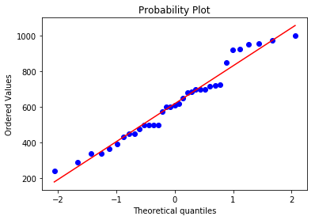

## Questão 3 - 5,0 pontos

[figure not shown]

Uma startup está desenvolvendo um aplicativo baseado em visão computacional para estimar o peso de um peixe utilizando apenas uma imagem. O aplicativo já é capaz de estimar todas as 5 medidas (`Length1`, `Length2`, `Length3`, `Height` e `Width`), mas agora precisam encontrar uma maneira de estimar o peso do peixe.

Sua tarefa é encontrar a variável **(apenas uma)** que seja mais relevante para explicar o peso do peixe utilizando um modelo linear. **Vamos considerar apenas os peixes da espécie *Bream***.

**a) [0,75 PONTOS]** Construa 5 gráficos de dispersão para analisar a relação de cada uma das 5 medidas (`Length1`, `Length2`, `Length3`, `Height` e `Width`) com o peso do peixe da espécie *Bream*. Deve ser possível identificar o que cada gráfico representa sem consultar o código, ou seja, os gráficos devem possuir títulos, no mínimo.

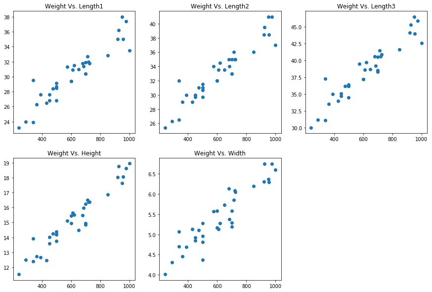

**b) [1,0 PONTO]** Ajuste um modelo linear **múltiplo** utilizando as 5 medidas para explicar a variável `Weight`. Neste item, **mostre** apenas os resultados desse ajuste.

OLS Regression Results

| Dep. Variable: | Weight | R-squared: | 0.943 |
| --- | --- | --- | --- |
| Model: | OLS | Adj. R-squared: | 0.933 |
| Method: | Least Squares | F-statistic: | 96.42 |
| Date: | Wed, 10 Jun 2020 | Prob (F-statistic): | 3.70e-17 |
| Time: | 23:48:00 | Log-Likelihood: | -185.96 |
| No. Observations: | 35 | AIC: | 383.9 |
| Df Residuals: | 29 | BIC: | 393.3 |
| Df Model: | 5 |  |  |
| Covariance Type: | nonrobust |  |  |

|  | coef | std err | t | P>\|t\| | [0.025 | 0.975] |
| --- | --- | --- | --- | --- | --- | --- |
| const | -939.4375 | 162.617 | -5.777 | 0.000 | -1272.026 | -606.849 |
| Length1 | 16.1878 | 49.401 | 0.328 | 0.746 | -84.849 | 117.225 |
| Length2 | 17.9695 | 53.705 | 0.335 | 0.740 | -91.869 | 127.808 |
| Length3 | -21.1881 | 42.259 | -0.501 | 0.620 | -107.617 | 65.241 |
| Height | 64.1981 | 17.841 | 3.598 | 0.001 | 27.709 | 100.687 |
| Width | 57.0522 | 42.139 | 1.354 | 0.186 | -29.131 | 143.235 |

| Omnibus: | 7.792 | Durbin-Watson: | 2.209 |
| --- | --- | --- | --- |
| Prob(Omnibus): | 0.020 | Jarque-Bera (JB): | 10.614 |
| Skew: | -0.407 | Prob(JB): | 0.00496 |
| Kurtosis: | 5.572 | Cond. No. | 1.14e+03 |

Warnings:  
[1] Standard Errors assume that the covariance matrix of the errors is correctly specified.  
[2] The condition number is large, 1.14e+03. This might indicate that there are  
strong multicollinearity or other numerical problems.

**c) [2,0 PONTOS]** Baseado no resultado do item *b*, quais das afirmações a seguir são verdadeiras? Indique sua resposta no Blackboard.

- A variável `Length2` é mais relevante para explicar a variável `Weight` do que a variável `Height`;
- Coeficientes negativos indicam que a variável não é relevante para explicar `Weight`;
- O valor-p associado ao coeficiente de `Height` indica que essa variável é significativa para explicar `Weight` (considere nível de significância 0,5%);
- De acordo com o resultado do teste Jarque-Bera podemos afirmar, com nível de significância de 1%, que a variável `Weight` segue uma distribuição normal;
- De acordo com o resultado do teste Omnibus podemos afirmar, com nível de significância de 5%, que os resíduos não seguem uma distribuição normal.

```
- [F] A variável `Length2` é mais relevante para explicar a variável `Weight` do que a variável `Height`;
- [F] Coeficientes negativos indicam que a variável não é relevante para explicar `Weight`;
- [V] O valor-p associado ao coeficiente de `Height` indica que essa variável é significativa para explicar `Weight` (considere nível de significância 0,5%);
- [F] De acordo com o resultado do teste Jarque-Bera podemos afirmar, com nível de significância de 1%, que a variável `Weight` segue uma distribuição normal;
- [V] De acordo com o resultado do teste Omnibus podemos afirmar, com nível de significância de 5%, que os resíduos não seguem uma distribuição normal.
```

**d) [0,75 PONTOS]** Remova as variáveis menos relevantes até que reste apenas a mais relevante. Ajuste um novo modelo linear utilizando apenas essa variável. É suficiente se você apresentar apenas o resultado final do ajuste com a variável mais relevante.

OLS Regression Results

| Dep. Variable: | Weight | R-squared: | 0.930 |
| --- | --- | --- | --- |
| Model: | OLS | Adj. R-squared: | 0.928 |
| Method: | Least Squares | F-statistic: | 440.5 |
| Date: | Wed, 10 Jun 2020 | Prob (F-statistic): | 1.16e-20 |
| Time: | 23:48:03 | Log-Likelihood: | -189.56 |
| No. Observations: | 35 | AIC: | 383.1 |
| Df Residuals: | 33 | BIC: | 386.2 |
| Df Model: | 1 |  |  |
| Covariance Type: | nonrobust |  |  |

|  | coef | std err | t | P>\|t\| | [0.025 | 0.975] |
| --- | --- | --- | --- | --- | --- | --- |
| const | -941.5590 | 74.896 | -12.571 | 0.000 | -1093.937 | -789.181 |
| Height | 102.7047 | 4.893 | 20.989 | 0.000 | 92.749 | 112.660 |

| Omnibus: | 1.780 | Durbin-Watson: | 2.282 |
| --- | --- | --- | --- |
| Prob(Omnibus): | 0.411 | Jarque-Bera (JB): | 0.784 |
| Skew: | 0.246 | Prob(JB): | 0.676 |
| Kurtosis: | 3.544 | Cond. No. | 121. |

Warnings:  
[1] Standard Errors assume that the covariance matrix of the errors is correctly specified.

**e) [0,5 PONTO]** Qual seria o peso, em gramas, de um peixe com as seguintes especificações utilizando o modelo ajustado no item *d*?

- `Length1`: 28
- `Length2`: 30
- `Length3`: 36
- `Height`: 16
- `Width`: 5

```
(701.7166181983623, 701.7162000000001)
```